# Assignment 3

Author

Your Name

Published

September 13, 2024

# Instructions

Complete the questions by adding the code under the relevant chunks.

Please submit your assignment as html file to me via email. Please call your assignment: “yourlastname_assignment3.html”. For example, I would submit something called “popescu_assignment3.html”. Please make sure that it is all in lower case.

To obtain the same look as this template, make sure that your you assignment preamble or YAML looks like below:

```yaml
---
title: "Assignment 3"
author: "Your Name"
date: "September 13, 2024"
format:
  html:
    toc: true
    number-sections: true
    colorlinks: true
    smooth-scroll: true
    embed-resources: true
---
```

Note that Headers such as “Question” need to be marked with `#` (i.e `# Question` will appear as header in bold and larger font after you render the document. It will thus appear in the Table of Contents). Regular text can just be written one line underneath.

```r
reticulate::use_python("/opt/anaconda3/bin/python", required = TRUE)
```

# 1 Question

Download the following dataset and load it into your computer’s memory.

This can be particularly useful in the context of [long customer reviews](https://www.dropbox.com/scl/fi/dq1h2ey9d6o78t7o2ylse/ps_5reviews.csv?rlkey=v8qqv2p26z3spgcg9sepznspi&st=9ocb8lpv&dl=0).

# 2 Question

Add a new column with the number of words per review and print the first 3 entries. Your entries should look like below:

| index | profile_name | rating | rating_date | title | review_text | word_count |
| --- | --- | --- | --- | --- | --- | --- |
| 0 | J.F. Carroll | 5.0 out of 5 stars | Reviewed in the United States on May 6, 2024 | 5.0 out of 5 stars\nIt's a PS5, everyone wants one, was there any doubt?\n | \nNobody could get their hands on this until just recently. It's a PS5, the craftmanship is awesome.Operates well, system works well with store, everything is easy, this console is a masterpiece and I… | 95 |
| 1 | Brandon | 5.0 out of 5 stars | Reviewed in the United States on April 17, 2024 | 5.0 out of 5 stars\nGreat Product, Great Price, Great Games!\n | \nI was looking for a great deal. Luckily, I found this product on sale for $450! I love this new PlayStation 5! I've been waiting years to get my own and now I have it! I use it vertically instead of… | 61 |
| 2 | Brock | 5.0 out of 5 stars | Reviewed in the United States on May 5, 2024 | 5.0 out of 5 stars\nAmazing Console\n | \nAfter using the playstation for over 4 months; I can say, this is one of the best consoles I’ve played on. I had an Xbox Series S and after playing on the PS5 there is a world of difference in graph… | 56 |

# 3 Question

How many words are there in the document-feature matrix? Write relevant code so that you obtain the following output:

```
Number of words: 1326
```

# 4 Question

How many documents are there in the document-feature matrix? Write code so that you obtain the following.

```
Number of documents: 100
```

# 5 Question

Create a barplot showing the profile names with the highest word count. Your barplot should look like below.

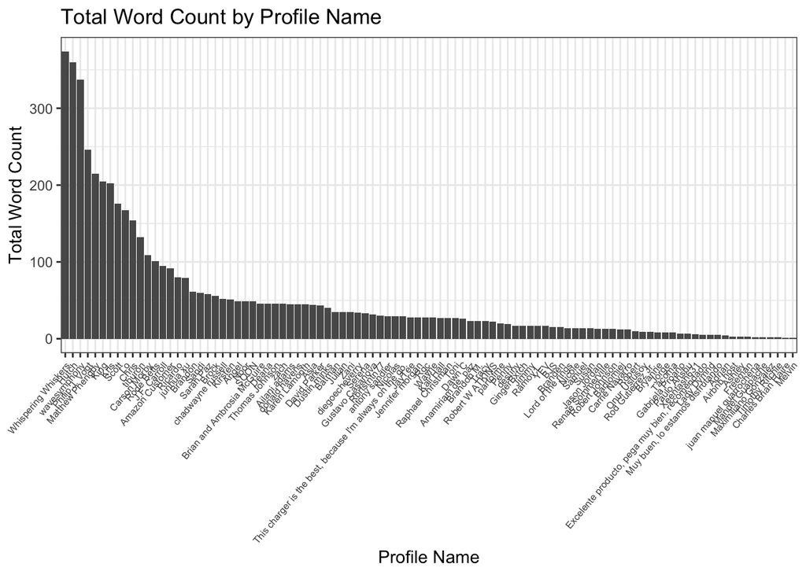

# 6 Question

What are the most common 15 words? Your barplot should look like this.

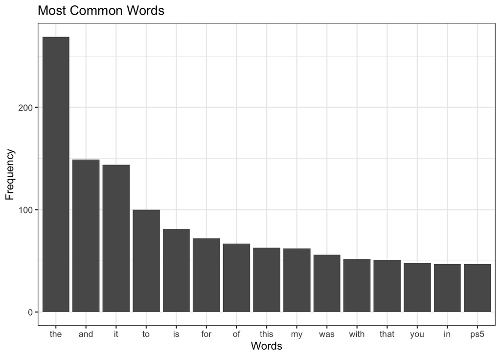

# 7 Question

Calculate the sparsity of all the documents. Your result should be:

```
0.9735746606334842
```

# 8 Question

Your graph should look like below:

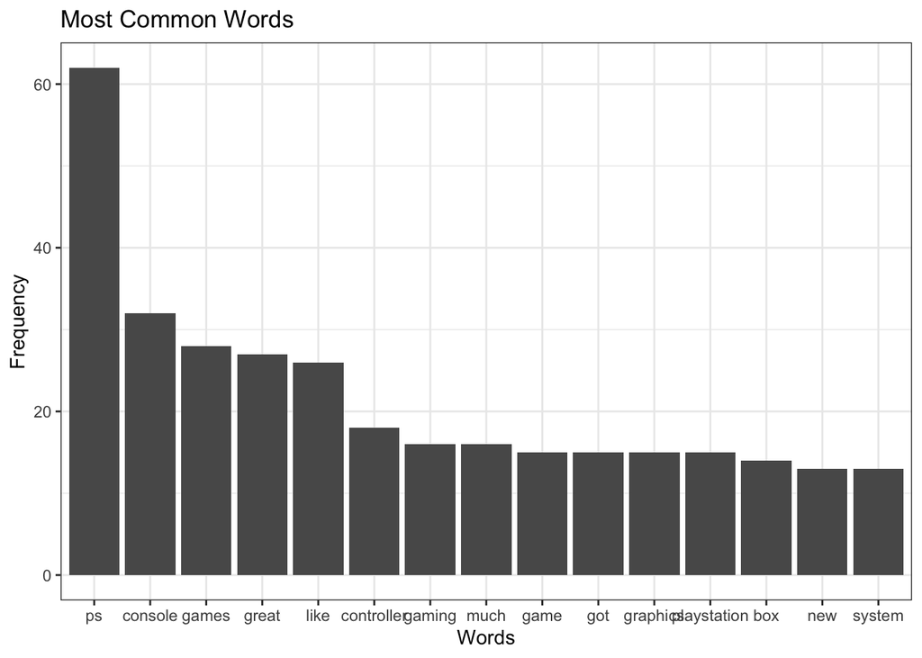

# 9 Question

Use OpenAI API to summarize customer reviews that are longer than 20 words. Ignore the reviews that have less than 20 words already. Print the first 5 summary reviews.

|  | profile_name | rating | rating_date | title | review_text | word_count | summary |
| --- | --- | --- | --- | --- | --- | --- | --- |
| 0 | J.F. Carroll | 5.0 out of 5 stars | Reviewed in the United States on May 6, 2024 | 5.0 out of 5 stars\nIt's a PS5, everyone wants one, was there any doubt?\n | \nNobody could get their hands on this until just recently. It's a PS5, the craftmanship is awesome.Operates well, system works well with store, everything is easy, this console is a masterpiece and I… | 95 | PS5 is finally in my hands. Craftsmanship is awesome, operates well, easy to use. Looks fantastic in real life. Playstation all the way. |
| 1 | Brandon | 5.0 out of 5 stars | Reviewed in the United States on April 17, 2024 | 5.0 out of 5 stars\nGreat Product, Great Price, Great Games!\n | \nI was looking for a great deal. Luckily, I found this product on sale for $450! I love this new PlayStation 5! I've been waiting years to get my own and now I have it! I use it vertically instead of… | 61 | Got a great deal on sale for $450! Love my new PlayStation 5, had to buy a $20 vertical stand. Highly recommend! |
| 2 | Brock | 5.0 out of 5 stars | Reviewed in the United States on May 5, 2024 | 5.0 out of 5 stars\nAmazing Console\n | \nAfter using the playstation for over 4 months; I can say, this is one of the best consoles I’ve played on. I had an Xbox Series S and after playing on the PS5 there is a world of difference in graph… | 56 | PS5 is the best console I've played on. Graphics, FPS, and loading times are superior to Xbox Series S. Spiderman game is spectacular. |
| 3 | Whispering Whiskers | 5.0 out of 5 stars | Reviewed in the United States on March 18, 2024 | 5.0 out of 5 stars\nEmbarking on a Next-Gen Adventure: An Honest Review of the PS5 Bundle\n | \nGreetings, fellow gamers! Gather 'round as I recount my leap into the realm of PlayStation with the illustrious PS5 Bundle. As someone who's long been immersed in the world of Xbox, I couldn't resis… | 374 | PS5 Bundle: Sleek design, fast SSD, stunning 4K visuals, immersive DualSense, limited storage, high price, worth the investment. Happy gaming! |
| 4 | Carson Morby | 5.0 out of 5 stars | Reviewed in the United States on May 8, 2024 | 5.0 out of 5 stars\nI finally go one!\n | \nFinally I got a PS5! I've been waiting forever, but I made the purchase because I heard NCAA Football 24 isn't coming out on PS4. Yep. I literally upgraded for that reason only :) So far it has been… | 109 | Got a PS5 for NCAA Football 24. Easy to use, long battery life, clear image, quiet, no complaints. Excited to explore more! |

# 10 Question

Calculate the Euclidean distance among the customer reviews. Print out the top two most similar customer reviews. Your output should look like:

```
**Similar Review Pair:**
Review 1:

I love it


Review 2:

Kids love it



**Similar Review Pair:**
Review 1:

👍🏻👍🏻👍🏻


Review 2:

Nice
```

# 11 Question

Now calculate the cosine similarity. Your output should look like:

```
**Most Similar Review Pair 1 (Cosine Similarity: 0.7487)**
Review 1:

best purchase yet


Review 2:

The best



**Most Similar Review Pair 2 (Cosine Similarity: 0.5471)**
Review 1:

Kids love it


Review 2:

I love it
```

# 12 Question

What is the difference between Euclidean Distance and Cosine Similarity? What are some caveats associated with using Euclidean Distance? What about Cosine Similarity?

# 13 Question

Make a wordcloud with all the customer reviews with the clean text unsing quanteda. Your output should look like below:

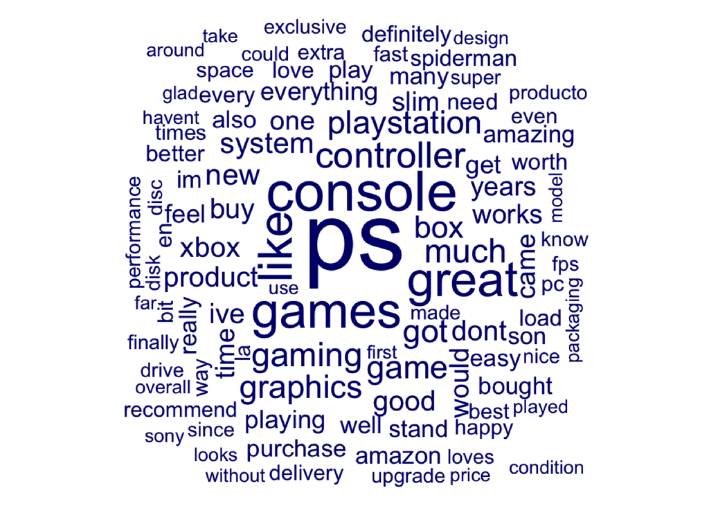